# AnalyticNotebook

Nicholas Parker

4/16/2022

```r
knitr::opts_chunk$set(echo = T,
                      results = "hold")
```

# Assignment 3 - Analytic Notebook

#### This is an analytic notebook for Assignement 3 describing the code used and the rationale for using it. We’re exploring data containing COVID-19 case counts for Germany, China, Japan, United Kingdom, US, Brazil, Mexico. We calculate the number of cases and rate of cases (cases/population) by country and day then produce a graph for the change in the number of cases and another for the change in rate by country. We then explore the influence of country, population, and the number of days since the panedemic began to determine their influence on overall case counts.

```r
# Adding packages to the R environment
library(tidyverse)
library(reshape2)
library(lubridate)
```

```r
# Creating the folder structure
# dir.create("./data")
# dir.create("./data/raw")
# dir.create("./data/clean")
# dir.create("./output")
# dir.create("./output/fig")
# dir.create("./output/tab")
# dir.create("./documentation")
# dir.create("./paper")
# dir.create("./scripts")

url_lookup_table<- "https://github.com/CSSEGISandData/COVID-19/blob/master/csse_covid_19_data/UID_ISO_FIPS_LookUp_Table.csv?raw=true"
url_global<- "https://github.com/CSSEGISandData/COVID-19/blob/master/csse_covid_19_data/csse_covid_19_time_series/time_series_covid19_confirmed_global.csv?raw=true"

lookup_table <- read_csv(url_lookup_table)
global_data<- read_csv(url_global)
global_data<- rename(global_data, "Combined_Key" = "Country/Region")

# Merging the lookup table and the COVID data,
combined_table <- left_join(global_data, lookup_table, "Combined_Key")

# Creating an aggregate cases variable, as some countries were broken up into regions.
cases <- combined_table %>%
  select(Country_Region,UID,iso2,iso3,Population, everything(),-code3,-FIPS, -Admin2, -Lat.x,-Lat.y, -Province_State,-Long_, -`Province/State`,-Long, -iso2,-iso3,-UID) %>%
  group_by(Combined_Key) %>%
  summarise_at(vars("1/22/20":"2/24/22"), sum, na.rm=TRUE)

# Creating a population variable for each country, as some were grouped by region.
population <- combined_table %>%
  select(Country_Region,UID,iso2,iso3,Population, everything(),-code3,-FIPS, -Admin2, -Lat.x,-Lat.y, -Province_State,-Long_, -`Province/State`,-Long, -iso2,-iso3,-UID) %>%
  group_by(Combined_Key) %>%
  summarise_at(vars(Population), mean, na.rm=TRUE)

# Merging the datasets using "Combined_Key" (the country variable).
combined_table_clean <- left_join(cases, population, "Combined_Key") %>%
  select(Combined_Key, Population, everything())

#Reshaping the data
data_long<- combined_table_clean %>%
  pivot_longer(
    cols = "1/22/20":"2/24/22",
    names_to = "date",
    values_to = "count"
  )

# Add lubridate package to help with formatting dates.
library(lubridate)

#Formatting the "date" as a date and generating the number of days since the pandemic began variable ("numdays")
data_long$date<- as_date(data_long$date, format="%m/%d/%y")
data_long$ref_date <- c("01/22/2020")
data_long$ref_date <- as_date(data_long$ref_date, format="%m/%d/%y")
data_long$numdays <- as.numeric(difftime(data_long$date, data_long$ref_date, units = "days"))
data_long<- data_long %>%
  filter(Combined_Key == "US" |Combined_Key=="Germany" |Combined_Key=="China"|Combined_Key=="United Kingdom"| Combined_Key=="Brazil"| Combined_Key=="Mexico"| Combined_Key=="Japan")

#create a table with the aggregate case count
aggregate_cases<- data_long %>%
  group_by(Combined_Key, date) %>%
  summarise_at(vars(count), max, na.rm=TRUE) %>%
  group_by(date) %>%
  summarise_at(vars(count), sum, na.rm=TRUE)

#converting to a data frame
aggregate_cases <- data.frame(aggregate_cases)

#cases per 100,000

data_long_percapita <- data_long %>%
  mutate(perht= Population/100000)

data_long_percapita<- data_long_percapita %>%
  mutate(count_perht= (count/perht))

data_long_percapita <- data.frame(data_long_percapita)

# connect to Spark server

# library(sparklyr)
#
##After connecting to Spark, all commands ran slowly, if at all. The professor told me to run the code on my maching instead of Spark but provide some commands I would have used to manipulate the data in Spark.
##Some dplyr commands work in Spark. I would have used the "filter" function to select the subset of countries we're interested in.
# sc <- spark_connect(master = "local",
#                     version = "2.3")
#
## Move onjects to the Spark server.
#
# cases_counts <- copy_to(sc, aggregate_cases, overwrite = T)
# cases_percapita <- copy_to(sc, data_long_percapita, overwrite = T)

## Filter data in Spark using dplyr. Referencing the object that references the data moved to the Spark server.
#
# cases_percapita_filtered <- cases_percapita %>%
#   filter(Combined_Key == "US" |Combined_Key=="Germany" |Combined_Key=="China"|Combined_Key=="United Kingdom"| #Combined_Key=="Brazil"| Combined_Key=="Mexico"| Combined_Key=="Japan")
#
## Describing the datato make certain the filter worked properly since we are unable to view the object in Spark.
#
# sdf_describe(cases_percapita_filtered, cols = c("Population", "count"))
#
```

# Plots

#### Below are plot for the aggregate daily case count among the selected countries and the rate of increase per 100,000 for each country, respectively.

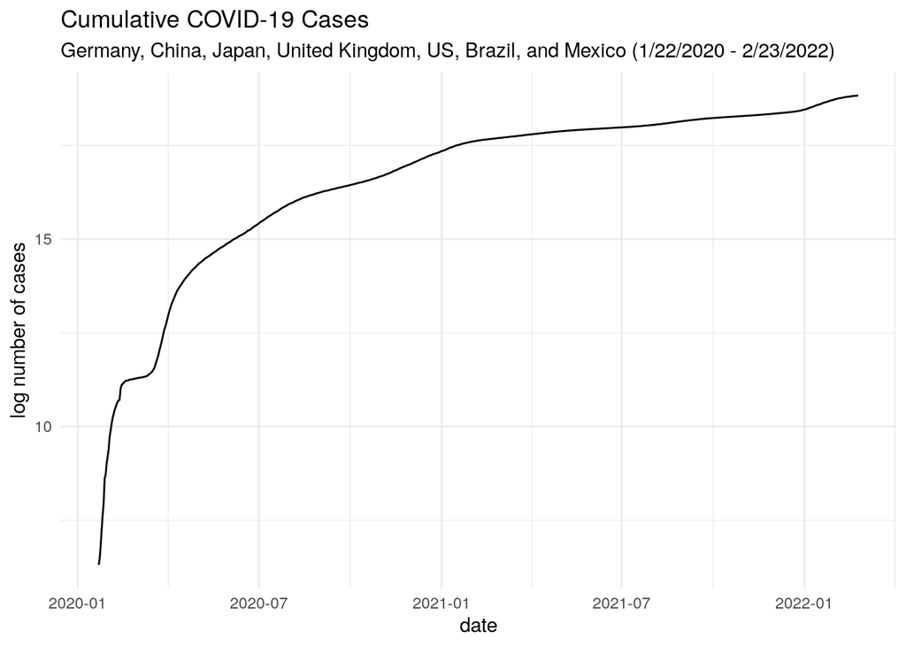

```r
#Plotting the aggregate case count
ggplot(data = aggregate_cases, aes(x = date, y = log(count), group=1))+
  theme_minimal()+
  geom_line() +
  xlab("date") +
  ylab("log number of cases")+
  labs(title="Cumulative COVID-19 Cases", subtitle = "Germany, China, Japan, United Kingdom, US, Brazil, and Mexico (1/22/2020 - 2/23/2022)")
```

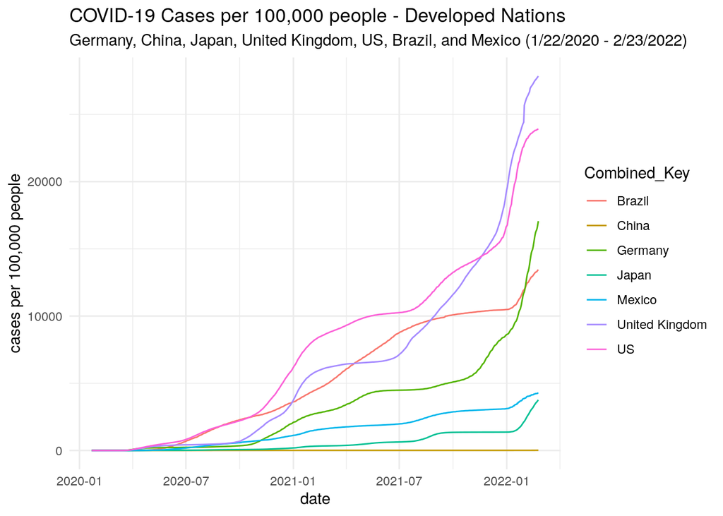

```r
# Plottign the daily rate of infection (per 100,000 people) for each country
ggplot(data = data_long_percapita, aes(x = date, y = count_perht,color=Combined_Key))+
  theme_minimal()+
  geom_line() +
  xlab("date") +
  ylab("cases per 100,000 people")+
  labs(title="COVID-19 Cases per 100,000 people - Developed Nations", subtitle = "Germany, China, Japan, United Kingdom, US, Brazil, and Mexico (1/22/2020 - 2/23/2022)")
```

# Linear Model

#### The model suggests that time (number of days since the pandemic began) had the largest influence on daily case counts. The country’s population also contributed to the growth in case counts. There was some dispersion in terms of the country effect on daily case counts likely reflecting the various public health approaches taken by authorities in each country.

```r
## regression - log of number of cases using: country, population size and day since the start of the pandemic.

#view data on Spark after making changes - sdf_describe(okc_train, cols = c("age", "income"))

##If using Spark, would use the ml_linear_regressions command from the Spark Machine learning library.

##model <- ml_linear_regression(cases_percapita,log(cases_percapita$count + 1) ~ cases_percapita$Population, cases_percapita$Combined_Key, cases_percapita$date)

library(texreg)
#Run a regression of the daily count of COVID cases on the number of days since the beginning of the pandemic, the country, and the population of the country.
model <- lm(count ~ numdays + Population + Combined_Key, data=data_long_percapita)
summary(model)
```

Call: lm(formula = count ~ numdays + Population + Combined_Key, data = data_long_percapita)

Residuals: Min 1Q Median 3Q Max -16815478 -3355753 -431036 3798394 44730245

Coefficients: (1 not defined because of singularities) Estimate Std. Error t value Pr(>|t|)  
(Intercept) -2.304e+07 8.683e+05 -26.539 <2e-16 *numdays 2.457e+04 4.349e+02 56.498 <2e-16* Population 1.164e-01 3.074e-03 37.870 <2e-16 *Combined_KeyChina -1.506e+08 3.520e+06 -42.775 <2e-16* Combined_KeyGermany 6.638e+06 6.560e+05 10.119 <2e-16 Combined_KeyJapan -3.603e+05 5.425e+05 -0.664 0.507  
Combined_KeyMexico 6.628e+05 5.392e+05 1.229 0.219  
Combined_KeyUnited Kingdom 1.011e+07 6.977e+05 14.489 <2e-16 Combined_KeyUS NA NA NA NA  
— Signif. codes: 0 ‘**’ 0.001 ’**’ 0.01 ’’ 0.05 ‘.’ 0.1 ’ ’ 1

Residual standard error: 7028000 on 5347 degrees of freedom Multiple R-squared: 0.6611, Adjusted R-squared: 0.6606 F-statistic: 1490 on 7 and 5347 DF, p-value: < 2.2e-16

```r
# Create a formatted HTML table containing the model's results
model_table <- htmlreg(model)

#Display the table
model_table
```

Statistical models

|  | Model 1 |
| --- | --- |
| (Intercept) | -23044036.87*** |
|  | (868292.76) |
| numdays | 24572.07*** |
|  | (434.92) |
| Population | 0.12*** |
|  | (0.00) |
| Combined_KeyChina | -150588838.07*** |
|  | (3520493.87) |
| Combined_KeyGermany | 6637865.58*** |
|  | (656000.99) |
| Combined_KeyJapan | -360257.55 |
|  | (542463.96) |
| Combined_KeyMexico | 662795.08 |
|  | (539156.02) |
| Combined_KeyUnited Kingdom | 10108798.24*** |
|  | (697674.79) |
| R<sup>2</sup> | 0.66 |
| Adj. R<sup>2</sup> | 0.66 |
| Num. obs. | 5355 |

***p < 0.001; **p < 0.01; *p < 0.05